# Generate figures in Simulation Analysis

Yunqing Liu & Ningshan Li

2023/08/07

# 1 Summary

This R Notebook generates figures in **Simulation Analysis** section in manuscript.

1. **Inputs**:
- [`CoarseGrain_Data.rds`](https://github.com/az7jh2/SDePER_Analysis/blob/main/Simulation/Generate_simulation_data/CoarseGrain_Data.rds): STARmap dataset used in simulation analysis.
- [`sim_spatial_spot_loc.csv`](https://github.com/az7jh2/SDePER_Analysis/blob/main/Simulation/Generate_simulation_data/sim_spatial_spot_loc.csv): locations of simulated spatial pseudo-spots.
- [`simulation_all_results.rds`](https://github.com/az7jh2/SDePER_Analysis/blob/main/Figures/Simulation/simulation_all_results.rds): cell type deconvolution results of all methods, as well as the ground truth in simulation analysis.
2. **Outputs**:
- Table S1. Median RMSE, JSD, correlation and FDR of all methods in Scenario 1
- Figure 2A. Visualization of STARmap dataset
- Figure 2B. Boxplot of performance of all methods in Scenario 1
- Figure 2C. Heatmap of proportion of eL2/3 in the simulated spatial pseudo-spots
- Figure 2D. Boxplot of performance of all methods with External reference in Scenario 1~3
- Figure S1. Correlations between proportions of all cell types in Scenario 1
- Figure S2. Heatmap of proportions of 4 cell types in the simulated spatial pseudo-spots

# 2 Version

```r
version[['version.string']]
```

```
[1] "R version 4.2.2 Patched (2022-11-10 r83330)"
```

```r
print(sprintf('Package %s version: %s', 'ggplot2', packageVersion('ggplot2')))
```

```
[1] "Package ggplot2 version: 3.4.2"
```

```r
print(sprintf('Package %s version: %s', 'ggpubr', packageVersion('ggpubr')))
```

```
[1] "Package ggpubr version: 0.6.0"
```

```r
print(sprintf('Package %s version: %s', 'philentropy', packageVersion('philentropy'))) # JSD function
```

```
[1] "Package philentropy version: 0.7.0"
```

# 3 Read relevant files

## 3.1 Read STARmap data

```r
file_name = file.path(home.dir, 'CoarseGrain_Data.rds')
STARmap_meta = readRDS(file_name)$meta
print(sprintf('load data from %s', file_name))
```

```
[1] "load data from /home/hill103/Documents/Spatial/Figures/Simulation/CoarseGrain_Data.rds"
```

## 3.2 Read locations of simulated spatial pseudo-spots

```r
file_name = file.path(home.dir, 'sim_spatial_spot_loc.csv')
sim_spot_loc = read.csv(file_name, row.names = 1, check.names = F)
print(sprintf('load data from %s', file_name))
```

```
[1] "load data from /home/hill103/Documents/Spatial/Figures/Simulation/sim_spatial_spot_loc.csv"
```

## 3.3 Read estimated cell type proportions by all methods

NOTE: in **SpatialDWLS** results there are fewer spots than ground truth.

```r
file_name = file.path(home.dir, 'simulation_all_results.rds')
all_res = readRDS(file_name)
print(sprintf('load data from %s', file_name))
```

```
[1] "load data from /home/hill103/Documents/Spatial/Figures/Simulation/simulation_all_results.rds"
```

```r
# check the order of spatial spots and cell types are consistent
all_spots = row.names(all_res[['Truth']])
all_celltypes_S1 = colnames(all_res[['Truth']])
all_celltypes_S2 = all_celltypes_S1[all_celltypes_S1!='VIP'] # in S2, we removed cell type VIP
all_celltypes_S3 = c(all_celltypes_S1, 'High Intronic') # in S3, we added one cell type High Intronic
```

Check the order of spots and cell types are consistent before performance evaluation.

```r
for (scenario in c("S1_int_ref", "S1_ext_ref", "S2_ext_ref", "S3_ext_ref")) {
  if (scenario %in% c("S1_int_ref", "S1_ext_ref")) {
    this_celltype_order = all_celltypes_S1
  } else if (scenario == 'S2_ext_ref') {
    this_celltype_order = all_celltypes_S2
  } else {
    this_celltype_order = all_celltypes_S3
  }

  for (method_name in names(all_res[[scenario]])) {
    # note in SpatialDWLS result there are fewer spots than ground truth
    if (nrow(all_res[[scenario]][[method_name]]) == nrow(all_res[['Truth']])) {
      stopifnot(all(row.names(all_res[[scenario]][[method_name]]) == all_spots))
    }
    stopifnot(all(colnames(all_res[[scenario]][[method_name]]) == this_celltype_order))
  }
}
```

Check whether negative values of estimated cell type proportions exist, as negative values may cause error in JSD calculation and got `NaN`. Replace them as 0.

```r
for (scenario in c("S1_int_ref", "S1_ext_ref", "S2_ext_ref", "S3_ext_ref")) {
  for (method_name in names(all_res[[scenario]])) {
    tmp_df = all_res[[scenario]][[method_name]]
    for (i in 1:nrow(tmp_df)) {
      for (j in 1:ncol(tmp_df)) {
        if (tmp_df[i, j] < 0) {
          print(sprintf('%s: %s result: row %d (%s) column %d (%s) has negative value %g', scenario, method_name, i, row.names(tmp_df)[i], j, colnames(tmp_df)[j], tmp_df[i, j]))
          # replace them with 0
          all_res[[scenario]][[method_name]][i, j] = 0
        }
      }
    }
  }
}
```

```
[1] "S1_int_ref: SpatialDWLS result: row 7 (x2534y550) column 6 (Endo) has negative value -3.10277e-19"
[1] "S1_int_ref: SpatialDWLS result: row 15 (x1034y1050) column 6 (Endo) has negative value -1.64163e-18"
[1] "S1_int_ref: SpatialDWLS result: row 94 (x9534y3050) column 4 (eL5) has negative value -8.5019e-19"
[1] "S1_int_ref: SpatialDWLS result: row 148 (x6034y4550) column 2 (eL2/3) has negative value -2.18279e-19"
[1] "S1_int_ref: SpatialDWLS result: row 177 (x34y5550) column 3 (eL4) has negative value -1.10594e-19"
[1] "S1_int_ref: SpatialDWLS result: row 220 (x2034y6550) column 3 (eL4) has negative value -3.4873e-19"
[1] "S1_int_ref: SpatialDWLS result: row 259 (x534y7550) column 5 (eL6) has negative value -4.86052e-19"
[1] "S1_int_ref: SpatialDWLS result: row 265 (x3534y7550) column 3 (eL4) has negative value -1.25912e-19"
[1] "S1_int_ref: SpatialDWLS result: row 339 (x34y9550) column 4 (eL5) has negative value -4.76472e-20"
[1] "S1_int_ref: SpatialDWLS result: row 344 (x2534y9550) column 7 (Micro) has negative value -2.45951e-18"
[1] "S1_int_ref: SpatialDWLS result: row 463 (x534y12550) column 3 (eL4) has negative value -1.32667e-18"
[1] "S1_int_ref: SpatialDWLS result: row 465 (x1534y12550) column 4 (eL5) has negative value -3.54592e-20"
[1] "S1_int_ref: SpatialDWLS result: row 540 (x3534y15050) column 3 (eL4) has negative value -1.90475e-18"
[1] "S1_int_ref: SpatialDWLS result: row 549 (x3034y16050) column 10 (Smc) has negative value -6.32663e-20"
[1] "S1_ext_ref: SpatialDWLS result: row 319 (x34y9050) column 4 (eL5) has negative value -2.78421e-19"
```

[output cut: 16 more lines]

Check whether estimated cell type proportions of spot are ALL 0s.

```r
for (scenario in c("S1_int_ref", "S1_ext_ref", "S2_ext_ref", "S3_ext_ref")) {
  for (method_name in names(all_res[[scenario]])) {
    tmp_df = all_res[[scenario]][[method_name]]
    for (i in 1:nrow(tmp_df)) {
      if (sum(tmp_df[i, ]) == 0) {
        print(sprintf('%s: %s result: row %d (%s) has ALL 0s', scenario, method_name, i, row.names(tmp_df)[i]))
      }
    }
  }
}
```

For the methods without cell type selection procedure, including **cell2location**, **DestVI**, **CARD** and **SONAR**, we put a hard-thresholding with cutoff **0.1** on the estimated cell type compositions to force the extremely small proportions to be zeros.

**UPDATE**: hard-thresholding were NOT applied, original estimated cell type proportions were used for performance evaluation.

# 4 Evaluate performance of cell type deconvolution methods

## 4.1 Calculate spot-wise performance of all methods

4 performance measurements:

- root mean square error (**RMSE**): quantifies the overall estimation accuracy
- Jensen-Shannon Divergence (**JSD**): assesses similarity between the estimated cell type distribution and ground-truth per spot
- **Pearson’s correlation coefficient**: measures the similarity of estimation to ground-truth
- false discovery rate (**FDR**): measures how many cell types were falsely predicted to be present

NOTE:

- in Scenario 2 we removed one cell type VIP. We manually add VIP back to the results of all methods and set its proportion as 0. The evaluation are based on all 12 cell types.
- in Scenario 3 we added one cell type High Intronic. We manually add High Intronic to ground truth and set its proportion as 0. The evaluation are based on 13 cell types.
- in **SpatialDWLS** results there are fewer spots than ground truth. The evaluation are based on spots with both truth and prediction only.

```r
binaryPredEvaluation = function(truth, pred) {
  # Given an array of truth and predictions (either 0 or 1), calculate confusion matrix
  # convert to factors to ensure get a full 2*2 confusion matrix
  truth_factor = factor(truth, levels = c(0, 1))
  pred_factor = factor(pred, levels = c(0, 1))
  # Generate confusion matrix
  conf_matrix = table(Actual = truth_factor, Predicted = pred_factor)
  # Extract elements of the confusion matrix
  TP = conf_matrix[2, 2]
  FP = conf_matrix[1, 2]
  FN = conf_matrix[2, 1]
  TN = conf_matrix[1, 1]
  # Calculate FDR (False Discovery Rate)
  FDR = FP / (TP + FP)
  # Calculate FNR (False Negative Rate)
  FNR = FN / (TP + FN)
  return(c(FDR, FNR))
}

calcPerformance = function(truth, pred) {
  # calculate RMSE, JSD, correlation and FDR for each row
  # inputs are matrix with rows as spots and columns as cell types, order has been checked to be consistent
  stopifnot(all(row.names(truth) == row.names(pred)))
  stopifnot(all(colnames(truth) == colnames(pred)))

  # binary cell type proportions (0:absent; 1:present)
  truth_binary = truth != 0
  pred_binary = pred != 0
  # in-place conversion from bool to 0/1 while keeping dimensions, row names and column names, as `as.numeric()` will "flattern" the original matrix
  truth_binary[] = as.numeric(truth_binary)
  pred_binary[] = as.numeric(pred_binary)

  perform_df = data.frame(matrix(ncol=5, nrow=0))
  colnames(perform_df) = c('RMSE', 'JSD', 'Pearson', 'FDR', 'FNR')

  for (i in 1:nrow(truth)) {
    RMSE = sqrt(mean((truth[i,] - pred[i,]) ^ 2))
    if (sum(pred[i,])>0 & sum(truth[i,])>0) {
      JSD = philentropy::JSD(rbind(truth[i,], pred[i,]), unit = 'log2', est.prob = 'empirical')
    } else {
      JSD = 1
    }
    Pearson = cor.test(truth[i,], pred[i,])$estimate
    tmp = binaryPredEvaluation(truth_binary[i,], pred_binary[i,])
    FDR = tmp[1]
    FNR = tmp[2]

    perform_df[nrow(perform_df)+1, ] = c(RMSE, JSD, Pearson, FDR, FNR)
  }

  # also record spot names
  stopifnot(nrow(perform_df) == nrow(truth))
  perform_df['Spot'] = row.names(truth)

  return(perform_df)
}


all_perform = list()

for (scenario in c("S1_int_ref", "S1_ext_ref", "S2_ext_ref", "S3_ext_ref")) {
  if (scenario %in% c("S1_int_ref", "S1_ext_ref", "S2_ext_ref")) {
    this_round_truth = all_res[['Truth']]
  } else {
    # add cell type High Intronic to Truth with 0 proportions
    this_round_truth = all_res[['Truth']]
    this_round_truth['High Intronic'] = 0
    this_round_truth = this_round_truth[, all_celltypes_S3]
  }

  all_perform[[scenario]] = list()
  for (method_name in names(all_res[[scenario]])) {
    this_pred = all_res[[scenario]][[method_name]]
    if (scenario == 'S2_ext_ref') {
      # add VIP back
      this_pred['VIP'] = 0
      this_pred = this_pred[, all_celltypes_S1]
    }

    if (method_name != 'SpatialDWLS') {
      all_perform[[scenario]][[method_name]] = calcPerformance(as.matrix(this_round_truth), as.matrix(this_pred))
    } else {
      this_truth = this_round_truth[row.names(this_pred),]
      all_perform[[scenario]][[method_name]] = calcPerformance(as.matrix(this_truth), as.matrix(this_pred))
    }
  }
}
```

## 4.2 Summary spot-wise performance into method-wise

Including Table S1. Median RMSE, JSD, correlation and FDR of all methods in Scenario 1.

```r
perform_raw_df = data.frame(matrix(ncol=9, nrow=0))
colnames(perform_raw_df) = c('Scenario', 'Method', 'Reference', 'Spot', 'RMSE', 'JSD', 'Pearson', 'FDR', 'FNR')

# calculate median performance across all spatial spots for all methods
perform_median_df = data.frame(matrix(ncol=8, nrow=0))
colnames(perform_median_df) = c('Scenario', 'Method', 'Reference', 'median_RMSE', 'median_JSD', 'median_Pearson', 'median_FDR', 'median_FNR')

for (scenario in c("S1_int_ref", "S1_ext_ref", "S2_ext_ref", "S3_ext_ref")) {
  if (scenario == "S1_int_ref") {
    this_scenario = 'Scenario 1'
    this_ref = 'Internal'
  } else if (scenario == "S1_ext_ref") {
    this_scenario = 'Scenario 1'
    this_ref = 'External'
  } else if (scenario == 'S2_ext_ref') {
    this_scenario = 'Scenario 2'
    this_ref = 'External'
  } else {
    this_scenario = 'Scenario 3'
    this_ref = 'External'
  }

  for (method_name in names(all_perform[[scenario]])) {
    tmp_df = all_perform[[scenario]][[method_name]]
    tmp_df['Scenario'] = this_scenario
    tmp_df['Method'] = method_name
    tmp_df['Reference'] = this_ref

    perform_raw_df = rbind(perform_raw_df, tmp_df[, c('Scenario', 'Method', 'Reference', 'RMSE', 'JSD', 'Pearson', 'FDR', 'FNR')])

    perform_median_df[nrow(perform_median_df)+1, ] = c(this_scenario, method_name, this_ref,
                                                       round(median(tmp_df$RMSE), 3),
                                                       round(median(tmp_df$JSD), 3),
                                                       round(median(tmp_df$Pearson), 3),
                                                       round(median(tmp_df$FDR), 3),
                                                       round(median(tmp_df$FNR), 3))
  }
}

# set method column as factors
perform_raw_df['Method'] = factor(perform_raw_df$Method, levels = method_order)

perform_median_df[, c('Scenario', 'Method', 'Reference', 'median_RMSE', 'median_JSD', 'median_Pearson', 'median_FDR', 'median_FNR')]
```

|  | Scenario | Method | Reference | median_RMSE | median_JSD | median_Pearson | median_FDR | median_FNR |
| --- | --- | --- | --- | --- | --- | --- | --- | --- |
| 1 | Scenario 1 | SDePER | Internal | 0.101 | 0.179 | 0.892 | 0.5 | 0.25 |
| 2 | Scenario 1 | GLRM | Internal | 0.067 | 0.097 | 0.948 | 0.5 | 0 |
| 3 | Scenario 1 | SpatialDWLS | Internal | 0.074 | 0.105 | 0.945 | 0.5 | 0 |
| 4 | Scenario 1 | cell2location | Internal | 0.114 | 0.241 | 0.833 | 0.833 | 0 |
| 5 | Scenario 1 | SPOTlight | Internal | 0.148 | 0.383 | 0.842 | 0.818 | 0 |
| 6 | Scenario 1 | CARD | Internal | 0.108 | 0.22 | 0.855 | 0.833 | 0 |
| 7 | Scenario 1 | DestVI | Internal | 0.197 | 0.589 | 0.303 | 0.833 | 0 |
| 8 | Scenario 1 | RCTD | Internal | 0.068 | 0.107 | 0.953 | 0.833 | 0 |
| 9 | Scenario 1 | SONAR | Internal | 0.062 | 0.092 | 0.958 | 0.833 | 0 |
| 10 | Scenario 1 | SDePER | External | 0.12 | 0.274 | 0.819 | 0.667 | 0 |

[output cut: 24 more lines]

# 5 Draw figures

## 5.1 Figure 2A. Visualization of STARmap dataset

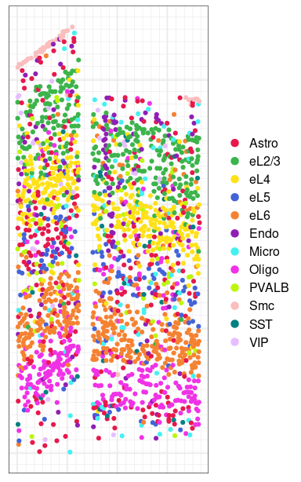

```r
grid_l = 500 # pixels of grid size for coarse graining in simulation

if (save_file) {
  file_name = file.path(home.dir, 'Fig2A_STARmap_visualization.pdf')
  cairo_pdf(file_name, height=6.4, width=4, onefile=T)
  print(sprintf('figures saved in file %s', file_name))
}

print(ggplot(STARmap_meta, aes(x=X, y=Y, color=cluster_name)) +
        geom_point() +
        scale_color_manual(values = my_color) +
        scale_x_continuous(minor_breaks = seq(min(STARmap_meta$X)-grid_l, max(STARmap_meta$X)+grid_l, grid_l)) +
        scale_y_continuous(minor_breaks = seq(min(STARmap_meta$Y)-grid_l, max(STARmap_meta$Y)+grid_l, grid_l)) +
        theme_bw() +
        theme(legend.title = element_blank(),
              axis.title = element_blank(),
              axis.text = element_blank(),
              axis.ticks = element_blank(),
              legend.text = element_text(size=12)) +
        guides(color = guide_legend(override.aes = list(size = 3))))
```

## 5.2 Figure 2B. Boxplot of performance of all methods in Scenario 1

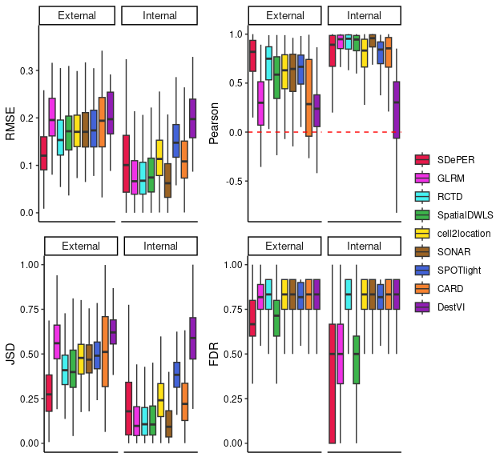

```r
if (save_file) {
  file_name = file.path(home.dir, 'Fig2B_S1_performance.pdf')
  cairo_pdf(file_name, height=6, width=6.5, onefile=T)
  print(sprintf('figures saved in file %s', file_name))
}

plot_df = perform_raw_df %>%
  filter(Scenario=='Scenario 1')

g_list = list()

for (perform_ind in c('RMSE', 'Pearson', 'JSD', 'FDR')) {
  g_list[[perform_ind]] = ggplot(plot_df, aes(x=Method, y=.data[[perform_ind]], fill=Method)) +
                            geom_boxplot(position=position_dodge(), outlier.shape=NA) +
                            scale_fill_manual(values=method_color) +
                            theme_classic() +
                            theme(strip.text = element_text(size=10),
                                  axis.text = element_text(color="black"),
                                  axis.ticks.x = element_blank(),
                                  axis.text.x = element_blank(),
                                  axis.title.x = element_blank(),
                                  legend.title = element_blank()) +
                            facet_grid(~Reference)
}

g_list[['Pearson']] = g_list[['Pearson']] + geom_hline(yintercept=0, color="red", linetype="dashed")

ggpubr::ggarrange(plotlist=g_list, ncol=2, nrow=2, common.legend=TRUE, legend="right")
```

## 5.3 Figure 2D. Boxplot of performance of all methods with External reference in Scenario 1~3

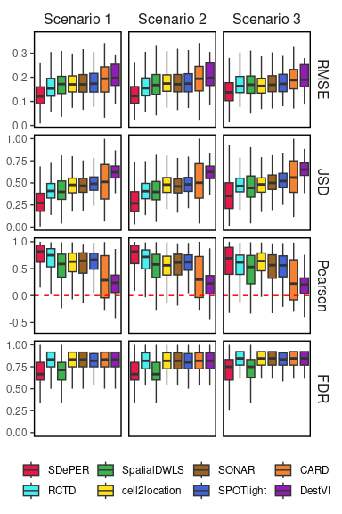

```r
if (save_file) {
  file_name = file.path(home.dir, 'Fig2D_S1-S3_ext_ref_performance.pdf')
  cairo_pdf(file_name, height=6, width=4, onefile=T)
  print(sprintf('figures saved in file %s', file_name))
}

dat_hline = data.frame(measure=c('Pearson'), yp=c(0))
# NOTE: we also need to add factor level to hline, otherwise the facet order of boxplots will be disturbed by hline
dat_hline['measure'] = factor(dat_hline$measure, levels = c('RMSE', 'JSD', 'Pearson', 'FDR'))

plot_df = perform_raw_df %>%
  filter(Reference=='External' & Method!='GLRM')

plot_df = tidyr::gather(plot_df[, c('Scenario', 'Method', 'Reference', 'RMSE', 'JSD', 'Pearson', 'FDR')], measure, value, RMSE:FDR, factor_key=F)

plot_df['measure'] = factor(plot_df$measure, levels = c('RMSE', 'JSD', 'Pearson', 'FDR'))
plot_df['Scenario'] = factor(plot_df$Scenario, levels = c('Scenario 1', 'Scenario 2', 'Scenario 3'))

ggplot(plot_df, aes(x=Method, y=value, fill=Method)) +
  geom_boxplot(position=position_dodge(), outlier.shape=NA) +
  scale_fill_manual(values=method_color) +
  facet_grid(measure~Scenario, scales='free_y') +
  theme_classic() +
  theme(panel.border = element_rect(fill=NA, colour="black", inherit.blank=T, size=1),
        strip.text = element_text(size=12), strip.background = element_rect(size=0),
        axis.ticks.x = element_blank(), axis.text.x = element_blank(), axis.title = element_blank(),
        axis.line = element_blank(), # avoid thick axis line in left and bottom border
        legend.position = "bottom", legend.title = element_blank()) +
  geom_hline(aes(yintercept = yp), data=dat_hline, color="red", linetype="dashed")
```

## 5.4 Figure 2C. Heatmap of proportion of eL2/3 in the simulated spatial pseudo-spots

For Scenario 1 with External reference

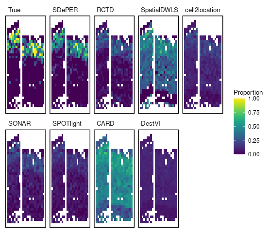

```r
if (save_file) {
  file_name = file.path(home.dir, 'Fig2C_eL23_prop_heatmap.pdf')
  cairo_pdf(file_name, height=5, width=5.8, onefile=T)
  print(sprintf('figures saved in file %s', file_name))
}

# A function to draw heatmap show the proportion of one cell type in simulated spots
# NOTE: When showing SpatialDWLS results, NOT show spots where there are no results from SpatialDWLS
onePropHeatmap = function(spot_loc, all_result, celltype, legend_pos='bottom', show_celltype=F) {
  # create dataframe for plot
  # first get the ground truth
  tmp_df = all_result[['Truth']][, celltype, drop=F]
  tmp_df['method'] = 'True'
  plot_df = merge(spot_loc[, c('imagerow', 'imagecol')], tmp_df, by='row.names')

  # add results of all methods (rbind will automatically check columns first)
  all_methods = method_order[method_order != 'GLRM']

  for (method in all_methods) {
    tmp_df = all_result[['S1_ext_ref']][[method]][, celltype, drop=F]
    tmp_df['method'] = method
    plot_df = rbind(plot_df, merge(spot_loc[, c('imagerow', 'imagecol')], tmp_df, by='row.names'))
  }

  plot_df['method'] = factor(plot_df$method, levels = c('True', all_methods))
  colnames(plot_df)[colnames(plot_df)==celltype] = 'Proportion'

  # draw heatmap
  g = ggplot(plot_df, aes(x=imagecol, y=imagerow, fill=Proportion)) +
    geom_tile() +
    viridis::scale_fill_viridis(limits = c(0, 1)) +
    theme_classic() +
    theme(panel.border = element_rect(fill=NA, colour="black", inherit.blank=T, size=1),
          strip.background = element_rect(size=0), strip.text = element_text(size=10, hjust=0),
          axis.title = element_blank(), axis.text = element_blank(), axis.ticks = element_blank(),
          axis.line = element_blank(), # avoid thick axis line in left and bottom border
          legend.title = element_text(size=10), legend.position = legend_pos,
          plot.title = element_text(hjust = 0.5, face = 'bold', margin = margin(t=10, b=0))) +
    facet_wrap(.~method, ncol = 5)

  if (show_celltype) {
    g = g + ggtitle(celltype)
  }

  return(g)
}

print(onePropHeatmap(sim_spot_loc, all_res, 'eL2/3', legend_pos = 'right'))
```

## 5.5 Figure S2. Heatmap of proportions of 4 cell types in the simulated spatial pseudo-spots

For Scenario 1 with External reference

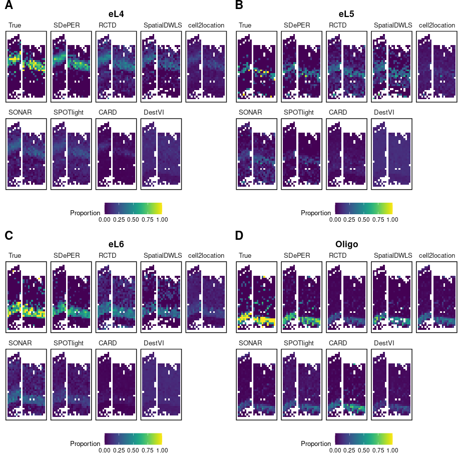

```r
if (save_file) {
  file_name = file.path(home.dir, 'FigS2_4celltypes_prop_heatmap.pdf')
  cairo_pdf(file_name, height=9.6, width=9.6, onefile=T)
  print(sprintf('figures saved in file %s', file_name))
}

ggpubr::ggarrange(onePropHeatmap(sim_spot_loc, all_res, 'eL4', legend_pos = 'bottom', show_celltype = T),
                  onePropHeatmap(sim_spot_loc, all_res, 'eL5', legend_pos = 'bottom', show_celltype = T),
                  onePropHeatmap(sim_spot_loc, all_res, 'eL6', legend_pos = 'bottom', show_celltype = T),
                  onePropHeatmap(sim_spot_loc, all_res, 'Oligo', legend_pos = 'bottom', show_celltype = T),
                  labels = c('A', 'B', 'C', 'D'), font.label = list(size=18), vjust = 1)
```

## 5.6 Figure S1. Correlations between proportions of all cell types in Scenario 1

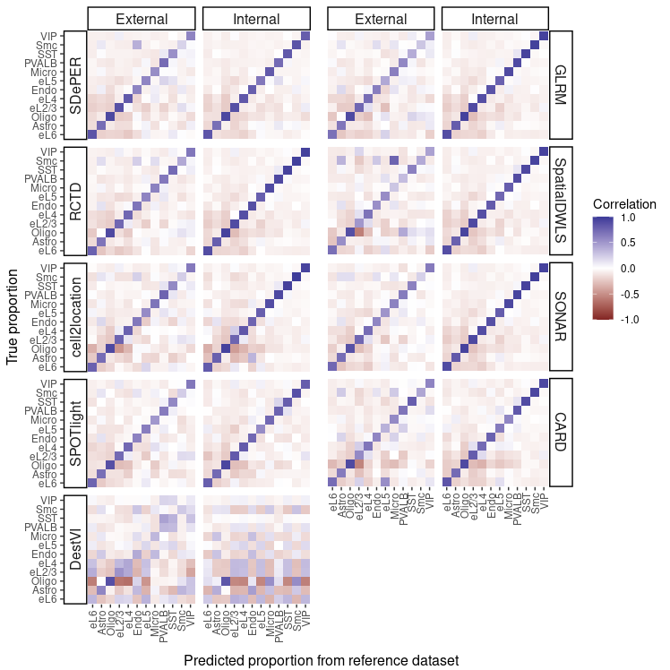

```r
if (save_file) {
  file_name = file.path(home.dir, 'FigS1_cor_allcelltypes_prop_heatmap.pdf')
  cairo_pdf(file_name, height=6, width=7.8, onefile=T)
  print(sprintf('figures saved in file %s', file_name))
}

celltype_order = c("eL6", "Astro", "Oligo", "eL2/3", "eL4", "Endo", "eL5", "Micro", "PVALB", "SST", "Smc", "VIP")

cor_df = data.frame(matrix(ncol=5, nrow=0))
colnames(cor_df) = c('Reference', 'Method', 'Correlation', 'celltype_truth', 'celltype_pred')

# calculate Pearson correlation of all cell types between Truth and method predictions
for (scenario in c("S1_int_ref", "S1_ext_ref")) {
  if (scenario == "S1_int_ref") {
    this_ref = 'Internal'
  } else if (scenario == "S1_ext_ref") {
    this_ref = 'External'
  }

  for (method_name in names(all_res[[scenario]])) {
    # cor(x,y) given x and y are matrices then the covariances (or correlations) between the columns of x and the columns of y are computed
    # in resulted correlation matrix, rows are columns from x, and columns are columns from y
    # NOTE: For SpatialDWLS results, omit spots with no results from SpatialDWLS
    if (method_name != 'SpatialDWLS') {
      tmp_cor = as.data.frame(cor(all_res[['Truth']], all_res[[scenario]][[method_name]]))
    } else {
      tmp_cor = as.data.frame(cor(all_res[['Truth']][row.names(all_res[[scenario]][[method_name]]),], all_res[[scenario]][[method_name]]))
    }

    tmp_cor['celltype_truth'] = row.names(tmp_cor)
    # convert all columns from wide to long, note rows of correlation matrix belong to Ground Truth
    tmp_cor_long = tidyr::gather(as.data.frame(tmp_cor), celltype_pred, Correlation, -celltype_truth)
    tmp_cor_long['Reference'] = this_ref
    tmp_cor_long['Method'] = method_name
    cor_df = rbind(cor_df, tmp_cor_long)
  }
}

cor_df['celltype_truth'] = factor(cor_df$celltype_truth, levels = celltype_order)
cor_df['celltype_pred'] = factor(cor_df$celltype_pred, levels = celltype_order)

# left panel: SDePER, RCTD, cell2location, SPOTlight, DestVI
plot_df = cor_df %>% filter(Method %in% c("SDePER", "RCTD", "cell2location", "SPOTlight", "DestVI"))
plot_df['Method'] = factor(plot_df$Method, levels = c("SDePER", "RCTD", "cell2location", "SPOTlight", "DestVI"))
g1 = ggplot(plot_df, aes(x=celltype_pred, y=celltype_truth, fill=Correlation)) +
  geom_tile() +
  scale_fill_gradient2(limits = c(-1, 1)) +
  theme_classic() +
  theme(strip.text = element_text(size=12),
        axis.title.x = element_blank(),
        axis.text.x = element_text(angle=90, vjust=0.5, hjust=1),
        axis.title.y = element_text(size=12, family="sans"), # to be consistent with the x axis title added by ggpubr::text_grob
        axis.line = element_blank(), # avoid thick axis line in left and bottom border
        legend.position = "none") +
  ylab("True proportion") +
  facet_grid(Method~Reference, switch = 'y')

# right panel: GLRM, SpatialDWLS, SONAR, CARD
plot_df = cor_df %>% filter(Method %in% c("GLRM", "SpatialDWLS", "SONAR", "CARD"))
plot_df['Method'] = factor(plot_df$Method, levels = c("GLRM", "SpatialDWLS", "SONAR", "CARD"))

g2 = ggplot(plot_df, aes(x=celltype_pred, y=celltype_truth, fill=Correlation)) +
  geom_tile() +
  scale_fill_gradient2(limits = c(-1, 1)) +
  theme_classic() +
  theme(strip.text = element_text(size=12),
        axis.text.x = element_text(angle=90, vjust=0.5, hjust=1),
        axis.text.y = element_blank(), axis.title.y = element_blank(), axis.ticks.y = element_blank(),
        axis.title.x = element_blank(),
        axis.line = element_blank(), # avoid thick axis line in left and bottom border
        legend.position = "right") +
  facet_grid(Method~Reference)

# we need a empty plot in right panel bottom
g2_plus_empty = ggpubr::ggarrange(g2, NULL, nrow = 2, ncol = 1, heights = c(1, 0.22), align = "v")

figure = ggpubr::ggarrange(g1, g2_plus_empty, widths = c(0.9, 1), align = "h")

# add common axis title in the center of two panels
ggpubr::annotate_figure(figure, bottom = ggpubr::text_grob("Predicted proportion from reference dataset", hjust=0.55))
```